# ADMET Multi-Task Learning — Analiza Eksperymentów

**Cel:** Zbudowanie modelu MTL, który konsekwentnie przewyższa Single-Task Learning (STL) na 13 zadaniach ADMET.

Każdy eksperyment to jedna konkretna modyfikacja bazowego modelu (`EXPERIMENT_MAIN`).

```python
import os, warnings
warnings.filterwarnings('ignore')
import numpy as np
import pandas as pd
import matplotlib.pyplot as plt
import matplotlib.patches as mpatches
import seaborn as sns
from IPython.display import display

plt.rcParams.update({'figure.dpi': 130, 'font.size': 11, 'axes.titlesize': 13})

# Ścieżka do EXPERIMENT/
# Notebook lezy w EXPERIMENT/, wiec BASE = folder notebooka
BASE = os.path.dirname(os.path.abspath('__file__'))
if not os.path.basename(BASE) == 'EXPERIMENT':
    BASE = os.path.join(os.getcwd(), 'EXPERIMENT')
# Przy nbconvert cwd może być inny — użyj ścieżki bezwzględnej
BASE = '/Users/jqbpoz/Projects/ADMET_MULTI_TASK_LEARNING/EXPERIMENT'
print(f'BASE: {BASE}')
```

```
BASE: /Users/jqbpoz/Projects/ADMET_MULTI_TASK_LEARNING/EXPERIMENT
```

## 1. Opis eksperymentów — rodzaj modyfikacji względem MAIN

| Eksperyment | Typ modyfikacji | Co się zmienia | Hipoteza |
| --- | --- | --- | --- |
| **MAIN** | Bazowy | GIN + MaskedBCELoss | Punkt odniesienia |
| **BALANCING** | Funkcja kosztu | pos_weight = neg/pos per task | Nierówne klasy — faworyzuje mniejszościową |
| **UNCERTAINTY** | Funkcja kosztu | Uczone skalary sigma^2 per task | Trudne taski dostają mniejszą wagę |
| **CROSS_UNCERT** | Funkcja kosztu | Macierz 13x13 sigma[i,j] — cross-task | Task i może wyciszyć task j jeśli kolidują |
| **PCGRAD** | Optymalizacja | Gradient Surgery — projekcja kolidujących gradientów | Eliminuje destruktywne interakcje gradientów |
| **GROUPING** | Architektura | Dwa backbone GIN: CYP-cluster vs reszta | Rozdziela gradienty na poziomie sieci |
| **EDGE_FEAT** | Architektura | GINEConv + 6 cech wiązań (typ, pierscien, konjugacja) | Dodatkowa informacja chemiczna |
| **VIRTUAL_NODE** | Preprocessing | Wirtualny wezel — globalny przepływ w 1 przeskoku | Pokonuje ograniczony zasięg 3-warstwowego GIN |

### Zadania ADMET (13 zbiorów)

| Klaster | Zadania |
| --- | --- |
| **CYP (metabolizm)** | cyp2c19, cyp2d6, cyp3a4, cyp1a2, cyp2c9 |
| **Transport/ADME** | hia_hou, pgp_broccatelli, bbb_martins |
| **Toksycznosc** | herg, dili, skin_reaction, ames, clintox |

```python
VARIANT = 'GNN_RDKIT_MORGAN'

EXPERIMENTS = {
    'MAIN':         ('EXPERIMENT_MAIN',             'MTL_GNN'),
    'BALANCING':    ('EXPERIMENT_BALANCING',         'MTL_GNN_BALANCED'),
    'UNCERTAINTY':  ('EXPERIMENT_UNCERTAINTY',       'MTL_GNN_UNCERTAINTY'),
    'CROSS_UNCERT': ('EXPERIMENT_CROSS_UNCERTAINTY', 'MTL_GNN_CROSS'),
    'PCGRAD':       ('EXPERIMENT_PCGRAD',            'MTL_GNN_PCGRAD'),
    'GROUPING':     ('EXPERIMENT_GROUPING',          'MTL_GNN_GROUPED'),
    'EDGE_FEAT':    ('EXPERIMENT_EDGE_FEATURES',     'MTL_GNN_EDGE'),
    'VIRTUAL_NODE': ('EXPERIMENT_VIRTUAL_NODE',      'MTL_GNN_VN'),
}

METHOD_COLORS = {
    'STL_GNN':      '#95a5a6',
    'MAIN':         '#2c3e50',
    'BALANCING':    '#e67e22',
    'UNCERTAINTY':  '#9b59b6',
    'CROSS_UNCERT': '#8e44ad',
    'PCGRAD':       '#27ae60',
    'GROUPING':     '#2980b9',
    'EDGE_FEAT':    '#c0392b',
    'VIRTUAL_NODE': '#16a085',
}

series = {}
for label, (exp_dir, col) in EXPERIMENTS.items():
    path = os.path.join(BASE, exp_dir, VARIANT, 'final_results.csv')
    if os.path.exists(path):
        df = pd.read_csv(path).set_index('Task')
        if col in df.columns:
            series[label] = df[col].rename(label)

main_df = pd.read_csv(os.path.join(BASE, 'EXPERIMENT_MAIN', VARIANT, 'final_results.csv')).set_index('Task')
stl = main_df['STL_GNN'].rename('STL_GNN')
xgb = main_df['XGBoost'].rename('XGBoost') if 'XGBoost' in main_df.columns else None

mtl  = pd.concat(series.values(), axis=1)
# XGB dodany do full — bierze udział we wszystkich heatmapach i rankingach
# XGB dostępny osobno do per-task porównań, NIE w full (avg XGB jest mylące)
full = pd.concat([stl, mtl], axis=1)
METHOD_COLORS['XGBoost'] = '#f39c12'
TASKS = list(full.index)

TASK_CLUSTERS = {
    'CYP':       [t for t in TASKS if 'cyp' in t],
    'Transport': ['hia_hou','pgp_broccatelli','bbb_martins'],
    'Tox':       ['herg','dili','skin_reaction','ames','clintox'],
}

print(f'Wczytano {len(series)} eksperymentow, {len(TASKS)} zadan')
print(full.round(4).to_string())
```

```
Wczytano 8 eksperymentow, 13 zadan
                 STL_GNN    MAIN  BALANCING  UNCERTAINTY  CROSS_UNCERT  PCGRAD  GROUPING  EDGE_FEAT  VIRTUAL_NODE
Task
hia_hou           0.9826  0.9810     0.9669       0.9864        0.9788  0.9902    0.9696     0.9805        0.9957
pgp_broccatelli   0.9046  0.9344     0.9107       0.9140        0.9218  0.9115    0.9356     0.9061        0.9257
bbb_martins       0.8650  0.8769     0.8724       0.8689        0.8739  0.8861    0.8688     0.8520        0.8610
cyp2c19_veith     0.8846  0.9073     0.8844       0.8748        0.8810  0.8984    0.9070     0.8996        0.8803
cyp2d6_veith      0.8403  0.8691     0.8533       0.8376        0.8474  0.8661    0.8671     0.8652        0.8395
cyp3a4_veith      0.8892  0.8984     0.8802       0.8685        0.8789  0.8951    0.9036     0.8976        0.8741
cyp1a2_veith      0.9261  0.9386     0.9204       0.9171        0.9207  0.9337    0.9388     0.9358        0.9262
cyp2c9_veith      0.8770  0.9071     0.8863       0.8707        0.8808  0.8993    0.9113     0.9077        0.8906
herg              0.8069  0.8186     0.7973       0.7611        0.8653  0.8214    0.8304     0.8097        0.8041
dili              0.8218  0.8457     0.7877       0.8719        0.8710  0.8568    0.8320     0.8351        0.8918
skin_reaction     0.6346  0.7124     0.7812       0.7188        0.6932  0.7360    0.6926     0.7079        0.6767
ames              0.8570  0.8789     0.8600       0.8487        0.8512  0.8812    0.8743     0.8739        0.8432
clintox           0.9066  0.9040     0.9238       0.9192        0.9233  0.9478    0.8780     0.8887        0.9037
```

## 2. Ranking ogólny — średni AUROC

```python
means = full.mean()
main_col = full['MAIN']
delta_main = full.subtract(main_col, axis=0).mean()
wins   = (full.subtract(main_col, axis=0) > 0).sum()
losses = (full.subtract(main_col, axis=0) < 0).sum()
beats_stl = (full.subtract(full['STL_GNN'], axis=0) > 0).sum()
ranking = pd.DataFrame({
    'Sr. AUROC':       means.round(4),
    'vs MAIN [pp]':    (delta_main * 100).round(2),
    'Wins vs MAIN':    wins,
    'Losses vs MAIN':  losses,
    'Bije STL (z 13)': beats_stl,
}).sort_values('Sr. AUROC', ascending=False)

def color_delta_r(val):
    if isinstance(val, float):
        if val > 0.1: return 'color: #27ae60; font-weight: bold'
        if val < -0.1: return 'color: #c0392b'
    return ''
def color_beats(val):
    if not isinstance(val, (int, float)): return ''
    if val >= 10: return 'background-color: #27ae6033; font-weight: bold'
    if val >= 7:  return 'background-color: #f39c1233'
    return 'background-color: #c0392b22'

display(ranking.style
    .format({'Sr. AUROC': '{:.4f}', 'vs MAIN [pp]': '{:+.2f} pp'})
    .applymap(color_delta_r, subset=['vs MAIN [pp]'])
    .applymap(color_beats, subset=['Bije STL (z 13)'])
    .background_gradient(subset=['Sr. AUROC'], cmap='YlGn')
    .set_caption(f'Ranking metod MTL + STL — wariant {VARIANT}'))
```

Ranking metod MTL + STL — wariant GNN_RDKIT_MORGAN

|  | Sr. AUROC | vs MAIN [pp] | Wins vs MAIN | Losses vs MAIN | Bije STL (z 13) |
| --- | --- | --- | --- | --- | --- |
| PCGRAD | 0.8864 | +0.39 pp | 7 | 6 | 13 |
| MAIN | 0.8825 | +0.00 pp | 0 | 0 | 11 |
| GROUPING | 0.8776 | -0.49 pp | 5 | 8 | 11 |
| CROSS_UNCERT | 0.8760 | -0.65 pp | 3 | 10 | 8 |
| EDGE_FEAT | 0.8738 | -0.87 pp | 1 | 12 | 10 |
| BALANCING | 0.8711 | -1.14 pp | 2 | 11 | 7 |
| VIRTUAL_NODE | 0.8702 | -1.23 pp | 2 | 11 | 6 |
| UNCERTAINTY | 0.8660 | -1.65 pp | 4 | 9 | 6 |
| STL_GNN | 0.8612 | -2.12 pp | 2 | 11 | 0 |

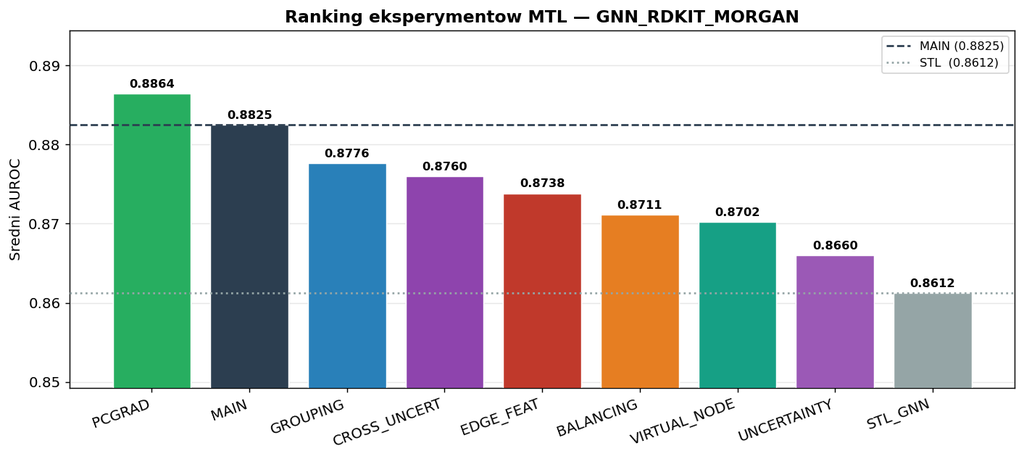

```python
fig, ax = plt.subplots(figsize=(11, 5))
sorted_cols = full.mean().sort_values(ascending=False).index
vals = full.mean()[sorted_cols]
colors = [METHOD_COLORS.get(c, '#7f8c8d') for c in sorted_cols]

bars = ax.bar(sorted_cols, vals, color=colors, edgecolor='white', linewidth=0.8, zorder=3)
ax.axhline(full['MAIN'].mean(), color='#2c3e50', linestyle='--', lw=1.5,
           label=f'MAIN ({full["MAIN"].mean():.4f})', zorder=4)
ax.axhline(full['STL_GNN'].mean(), color='#95a5a6', linestyle=':', lw=1.5,
           label=f'STL  ({full["STL_GNN"].mean():.4f})', zorder=4)
# XGBoost nie pokazany na avg — patrz per-task tabele w sekcji 5

for bar, val in zip(bars, vals):
    ax.text(bar.get_x() + bar.get_width()/2, val + 0.0005, f'{val:.4f}',
            ha='center', va='bottom', fontsize=9, fontweight='bold')

ax.set_ylim(min(vals) - 0.012, max(vals) + 0.008)
ax.set_ylabel('Sredni AUROC')
ax.set_title(f'Ranking eksperymentow MTL — {VARIANT}', fontweight='bold')
ax.legend(fontsize=9)
ax.grid(axis='y', alpha=0.3, zorder=0)
ax.set_xticklabels(sorted_cols, rotation=20, ha='right')
plt.tight_layout()
plt.show()
```

## 3. Heatmapa AUROC — wszystkie metody × wszystkie zadania

[figure not shown]

```python
col_order = ['STL_GNN'] + [c for c in full.columns if c != 'STL_GNN']
heat_data = full[col_order].T

fig, ax = plt.subplots(figsize=(17, 6))
sns.heatmap(heat_data.astype(float), annot=True, fmt='.3f', cmap='RdYlGn',
            linewidths=0.4, linecolor='white', vmin=0.65, vmax=1.0, ax=ax,
            cbar_kws={'label': 'AUROC', 'shrink': 0.7})

for b in [5, 8]:
    ax.axvline(b, color='#2c3e50', linewidth=2.5)

ax.set_title(f'AUROC per task x eksperyment — {VARIANT}', fontweight='bold', pad=12)
ax.set_xticklabels(ax.get_xticklabels(), rotation=30, ha='right', fontsize=9)

for lbl, (s, e) in [('CYP', (0,5)), ('Transport', (5,8)), ('Toksycznosc', (8,13))]:
    ax.text((s+e)/2, -0.5, lbl, ha='center', va='top', fontsize=9, fontweight='bold',
            color='#2c3e50', transform=ax.get_xaxis_transform())

plt.tight_layout()
plt.show()
```

## 4. Delta AUROC vs MAIN — per metoda i zadanie

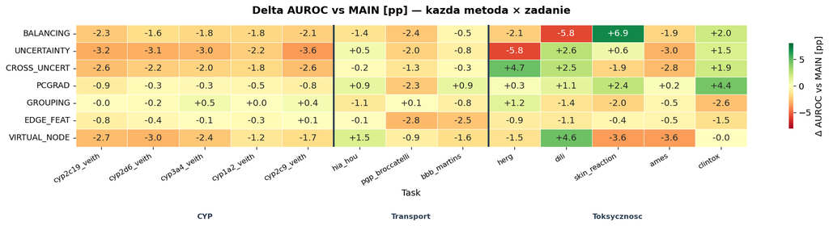

```python
methods = [c for c in full.columns if c not in ('STL_GNN', 'MAIN')]
delta_df = full[methods].subtract(full['MAIN'], axis=0) * 100  # pp

# Reorder tasks: CYP | Transport | Tox
task_order = (
    [t for t in TASKS if 'cyp' in t] +
    ['hia_hou','pgp_broccatelli','bbb_martins'] +
    ['herg','dili','skin_reaction','ames','clintox']
)
task_order = [t for t in task_order if t in delta_df.index]
plot_data = delta_df.loc[task_order].T  # methods × tasks

fig, ax = plt.subplots(figsize=(16, 5))
sns.heatmap(
    plot_data.astype(float),
    annot=True, fmt='+.1f', cmap='RdYlGn', center=0,
    linewidths=0.5, linecolor='white',
    vmin=-8, vmax=8, ax=ax,
    cbar_kws={'label': 'Δ AUROC vs MAIN [pp]', 'shrink': 0.7},
)

# Cluster separators (columns = tasks)
cyp_count = len([t for t in task_order if 'cyp' in t])
transport_count = 3
ax.axvline(cyp_count, color='#2c3e50', linewidth=2.2)
ax.axvline(cyp_count + transport_count, color='#2c3e50', linewidth=2.2)

ax.set_title('Delta AUROC vs MAIN [pp] — kazda metoda × zadanie', fontweight='bold', pad=14)
ax.set_xticklabels(ax.get_xticklabels(), rotation=30, ha='right', fontsize=9)
ax.set_yticklabels(ax.get_yticklabels(), rotation=0, fontsize=10)

for lbl, (s, e) in [('CYP', (0, cyp_count)),
                     ('Transport', (cyp_count, cyp_count+transport_count)),
                     ('Toksycznosc', (cyp_count+transport_count, len(task_order)))]:
    ax.text((s+e)/2, -0.55, lbl, ha='center', va='top', fontsize=9, fontweight='bold',
            color='#2c3e50', transform=ax.get_xaxis_transform())

plt.tight_layout()
plt.show()
```

## 5. Najlepsza metoda per zadanie

```python
# ── Szukamy globalnego najlepszego: wszystkie eksperymenty × wszystkie warianty ──
ALL_VARIANTS = ['GNN', 'GNN_MORGAN', 'GNN_RDKIT', 'GNN_RDKIT_MORGAN']

ADMET_GROUPS = {
    'Absorption': ['hia_hou', 'pgp_broccatelli', 'bbb_martins'],
    'Metabolism': ['cyp2c19_veith','cyp2d6_veith','cyp3a4_veith','cyp1a2_veith','cyp2c9_veith'],
    'Toxicity':   ['herg','dili','skin_reaction','ames','clintox'],
}
task_to_group = {t: g for g, ts in ADMET_GROUPS.items() for t in ts}

# Zbierz WSZYSTKIE wyniki (exp x variant)
records = []
for exp_label, (exp_dir, col) in EXPERIMENTS.items():
    for var in ALL_VARIANTS:
        p = os.path.join(BASE, exp_dir, var, 'final_results.csv')
        if not os.path.exists(p): continue
        df = pd.read_csv(p).set_index('Task')
        if col not in df.columns: continue
        for task, val in df[col].items():
            if not np.isnan(val):
                records.append({'Task': task, 'Metoda': exp_label, 'Wariant': var, 'AUROC': val})

all_res = pd.DataFrame(records)
# Referencja musi być zdefiniowana przed global_best
main_ref = pd.read_csv(os.path.join(BASE,'EXPERIMENT_MAIN','GNN_RDKIT_MORGAN','final_results.csv')).set_index('Task')
stl_ref  = main_ref['STL_GNN']
xgb_ref  = main_ref['XGBoost'] if 'XGBoost' in main_ref.columns else None
main_mtl = main_ref['MTL_GNN']

global_best = all_res.loc[all_res.groupby('Task')['AUROC'].idxmax()].set_index('Task')

# (main_ref, stl_ref, xgb_ref, main_mtl już zdefiniowane powyżej)

row = {
    'ADMET':              pd.Series({t: task_to_group.get(t,'?') for t in global_best.index}),
    'XGBoost':            xgb_ref.round(4) if xgb_ref is not None else float('nan'),
    'STL_GNN':            stl_ref.round(4),
    'MAIN':               main_mtl.round(4),
    'Najlepsza metoda':   global_best['Metoda'].reindex(stl_ref.index),
    'Wariant wejsc':      global_best['Wariant'].reindex(stl_ref.index),
    'Najlepszy AUROC':    global_best['AUROC'].reindex(stl_ref.index).round(4),
    'vs MAIN [pp]':  ((global_best['AUROC'].reindex(stl_ref.index) - main_mtl) * 100).round(2),
    'vs STL [pp]':   ((global_best['AUROC'].reindex(stl_ref.index) - stl_ref)  * 100).round(2),
    'MTL > STL':     (global_best['AUROC'].reindex(stl_ref.index) > stl_ref).map({True:'YES',False:'NO'}),
}
if xgb_ref is not None:
    gb_auroc = global_best['AUROC'].reindex(xgb_ref.index)
    row['vs XGB [pp]'] = ((gb_auroc - xgb_ref) * 100).round(2)
    row['MTL > XGB']   = (gb_auroc > xgb_ref).map({True:'YES',False:'NO'})

per_task_global = pd.DataFrame(row)

def color_bool2(val):
    return 'color: #27ae60; font-weight: bold' if val == 'YES' else 'color: #c0392b; font-weight: bold'

def color_delta2(val):
    if isinstance(val, float):
        if val > 0.5:  return 'color: #27ae60; font-weight: bold'
        if val < -0.5: return 'color: #c0392b'
    return ''

def color_group(val):
    p = {'Absorption':'#dce9f7','Metabolism':'#fef3cd','Toxicity':'#fde8e8'}
    return f'background-color: {p.get(val,"")}; font-weight: bold'

def color_variant(val):
    vc = {'GNN':'#d5e8d4','GNN_MORGAN':'#ffe6cc','GNN_RDKIT':'#e1d5e7','GNN_RDKIT_MORGAN':'#d5f5e3'}
    return f'background-color: {vc.get(val,"")}'

fmt = {
    'XGBoost':'{:.4f}','STL_GNN':'{:.4f}','MAIN':'{:.4f}','Najlepszy AUROC':'{:.4f}',
    'vs MAIN [pp]':'{:+.2f} pp','vs STL [pp]':'{:+.2f} pp',
}
bool_cols  = ['MTL > STL']
delta_cols = ['vs MAIN [pp]','vs STL [pp]']
if xgb_ref is not None:
    fmt['vs XGB [pp]'] = '{:+.2f} pp'
    bool_cols.append('MTL > XGB')
    delta_cols.append('vs XGB [pp]')

display(per_task_global.style
    .format(fmt)
    .applymap(color_bool2,   subset=bool_cols)
    .applymap(color_delta2,  subset=delta_cols)
    .background_gradient(subset=['Najlepszy AUROC'], cmap='YlGn')
    .set_caption('GLOBALNIE — Najlepszy wynik MTL per zadanie (wszystkie metody × wszystkie warianty wejsc)'))

n_stl = (global_best['AUROC'].reindex(stl_ref.index) > stl_ref).sum()
n_xgb = (global_best['AUROC'].reindex(xgb_ref.index) > xgb_ref).sum() if xgb_ref is not None else '?'
print(f'\nNajlepsza MTL bije STL na {n_stl}/13 zadaniach')
if xgb_ref is not None:
    print(f'Najlepsza MTL bije XGB  na {n_xgb}/13 zadaniach')
```

GLOBALNIE — Najlepszy wynik MTL per zadanie (wszystkie metody × wszystkie warianty wejsc)

|  | ADMET | XGBoost | STL_GNN | MAIN | Najlepsza metoda | Wariant wejsc | Najlepszy AUROC | vs MAIN [pp] | vs STL [pp] | MTL > STL | vs XGB [pp] | MTL > XGB |
| --- | --- | --- | --- | --- | --- | --- | --- | --- | --- | --- | --- | --- |
| ames | Toxicity | 0.8930 | 0.8570 | 0.8789 | GROUPING | GNN_RDKIT | 0.8883 | +0.94 pp | +3.13 pp | YES | -0.48 pp | NO |
| bbb_martins | Absorption | 0.9008 | 0.8650 | 0.8769 | VIRTUAL_NODE | GNN_RDKIT | 0.9187 | +4.18 pp | +5.37 pp | YES | +1.79 pp | YES |
| clintox | Toxicity | 0.9226 | 0.9066 | 0.9040 | PCGRAD | GNN_RDKIT_MORGAN | 0.9478 | +4.39 pp | +4.12 pp | YES | +2.53 pp | YES |
| cyp1a2_veith | Metabolism | 0.9345 | 0.9261 | 0.9386 | EDGE_FEAT | GNN | 0.9417 | +0.31 pp | +1.56 pp | YES | +0.73 pp | YES |
| cyp2c19_veith | Metabolism | 0.8913 | 0.8846 | 0.9073 | BALANCING | GNN_MORGAN | 0.9103 | +0.30 pp | +2.57 pp | YES | +1.90 pp | YES |
| cyp2c9_veith | Metabolism | 0.8986 | 0.8770 | 0.9071 | GROUPING | GNN_RDKIT_MORGAN | 0.9113 | +0.41 pp | +3.42 pp | YES | +1.27 pp | YES |
| cyp2d6_veith | Metabolism | 0.8654 | 0.8403 | 0.8691 | EDGE_FEAT | GNN | 0.8715 | +0.24 pp | +3.12 pp | YES | +0.61 pp | YES |
| cyp3a4_veith | Metabolism | 0.8889 | 0.8892 | 0.8984 | GROUPING | GNN_RDKIT_MORGAN | 0.9036 | +0.52 pp | +1.44 pp | YES | +1.47 pp | YES |
| dili | Toxicity | 0.8648 | 0.8218 | 0.8457 | VIRTUAL_NODE | GNN_RDKIT | 0.9207 | +7.49 pp | +9.88 pp | YES | +5.59 pp | YES |
| herg | Toxicity | 0.8162 | 0.8069 | 0.8186 | UNCERTAINTY | GNN_RDKIT | 0.8839 | +6.52 pp | +7.70 pp | YES | +6.77 pp | YES |
| hia_hou | Absorption | 0.9864 | 0.9826 | 0.9810 | VIRTUAL_NODE | GNN_RDKIT_MORGAN | 0.9957 | +1.47 pp | +1.30 pp | YES | +0.92 pp | YES |
| pgp_broccatelli | Absorption | 0.9342 | 0.9046 | 0.9344 | GROUPING | GNN_RDKIT_MORGAN | 0.9356 | +0.12 pp | +3.10 pp | YES | +0.14 pp | YES |
| skin_reaction | Toxicity | 0.7551 | 0.6346 | 0.7124 | BALANCING | GNN_RDKIT_MORGAN | 0.7812 | +6.89 pp | +14.67 pp | YES | +2.61 pp | YES |

```
Najlepsza MTL bije STL na 13/13 zadaniach
Najlepsza MTL bije XGB  na 12/13 zadaniach
```

## 5b. Najlepsza metoda per zadanie — per wariant wejść

```python
VARIANTS = ['GNN', 'GNN_MORGAN', 'GNN_RDKIT', 'GNN_RDKIT_MORGAN']

for var in VARIANTS:
    # Wczytaj wszystkie eksperymenty dla tego wariantu
    s = {}
    for label, (exp_dir, col) in EXPERIMENTS.items():
        p = os.path.join(BASE, exp_dir, var, 'final_results.csv')
        if os.path.exists(p):
            df = pd.read_csv(p).set_index('Task')
            if col in df.columns:
                s[label] = df[col].rename(label)

    if not s:
        continue

    f_var = pd.concat(s.values(), axis=1)

    # STL i XGBoost z MAIN dla tego wariantu
    main_p = os.path.join(BASE, 'EXPERIMENT_MAIN', var, 'final_results.csv')
    if not os.path.exists(main_p):
        continue
    main_v = pd.read_csv(main_p).set_index('Task')
    stl_v  = main_v['STL_GNN']
    xgb_v  = main_v['XGBoost'] if 'XGBoost' in main_v.columns else None

    bm = f_var.idxmax(axis=1)
    bs = f_var.max(axis=1)

    row = {
        'XGBoost':              xgb_v.round(4) if xgb_v is not None else float('nan'),
        'STL_GNN':              stl_v.round(4),
        'MAIN':                 f_var['MAIN'].round(4) if 'MAIN' in f_var.columns else float('nan'),
        'Najlepsza metoda':     bm,
        'Najlepszy AUROC':      bs.round(4),
        'Delta vs MAIN [pp]':   ((bs - f_var['MAIN']) * 100).round(2) if 'MAIN' in f_var.columns else float('nan'),
        'Delta vs STL [pp]':    ((bs - stl_v) * 100).round(2),
        'MTL bije STL?':        (bs > stl_v).map({True: 'TAK', False: 'NIE'}),
    }
    if xgb_v is not None:
        row['Delta vs XGB [pp]'] = ((bs - xgb_v) * 100).round(2)
        row['MTL bije XGB?']     = (bs > xgb_v).map({True: 'TAK', False: 'NIE'})

    tbl = pd.DataFrame(row)

    fmt = {
        'XGBoost': '{:.4f}', 'STL_GNN': '{:.4f}', 'MAIN': '{:.4f}',
        'Najlepszy AUROC':    '{:.4f}',
        'Delta vs MAIN [pp]': '{:+.2f} pp',
        'Delta vs STL [pp]':  '{:+.2f} pp',
    }
    bool_cols  = ['MTL bije STL?']
    delta_cols = ['Delta vs MAIN [pp]', 'Delta vs STL [pp]']
    if xgb_v is not None:
        fmt['Delta vs XGB [pp]'] = '{:+.2f} pp'
        bool_cols.append('MTL bije XGB?')
        delta_cols.append('Delta vs XGB [pp]')

    def color_bool(val):
        return 'color: #27ae60; font-weight: bold' if val == 'TAK' else 'color: #c0392b'

    def color_delta(val):
        if isinstance(val, float):
            if val > 0.5: return 'color: #27ae60; font-weight: bold'
            if val < -0.5: return 'color: #c0392b'
        return ''

    n_xgb = (bs > xgb_v).sum() if xgb_v is not None else '?'
    n_stl = (bs > stl_v).sum()

    display(tbl.style
        .format(fmt)
        .applymap(color_bool,  subset=bool_cols)
        .applymap(color_delta, subset=delta_cols)
        .background_gradient(subset=['Najlepszy AUROC'], cmap='YlGn')
        .set_caption(f'Wariant: {var} | Bije STL: {n_stl}/13 | Bije XGB: {n_xgb}/13'))
    print()
```

Wariant: GNN | Bije STL: 12/13 | Bije XGB: 12/13

| Task | XGBoost | STL_GNN | MAIN | Najlepsza metoda | Najlepszy AUROC | Delta vs MAIN [pp] | Delta vs STL [pp] | MTL bije STL? | Delta vs XGB [pp] | MTL bije XGB? |
| --- | --- | --- | --- | --- | --- | --- | --- | --- | --- | --- |
| hia_hou | 0.9137 | 0.9680 | 0.9848 | PCGRAD | 0.9935 | +0.87 pp | +2.55 pp | TAK | +7.98 pp | TAK |
| pgp_broccatelli | 0.8987 | 0.8975 | 0.9211 | UNCERTAINTY | 0.9243 | +0.32 pp | +2.68 pp | TAK | +2.55 pp | TAK |
| bbb_martins | 0.8130 | 0.8742 | 0.8776 | BALANCING | 0.8938 | +1.62 pp | +1.96 pp | TAK | +8.08 pp | TAK |
| cyp2c19_veith | 0.7727 | 0.8862 | 0.8988 | GROUPING | 0.9079 | +0.90 pp | +2.17 pp | TAK | +13.52 pp | TAK |
| cyp2d6_veith | 0.7382 | 0.8347 | 0.8694 | EDGE_FEAT | 0.8715 | +0.20 pp | +3.67 pp | TAK | +13.32 pp | TAK |
| cyp3a4_veith | 0.7746 | 0.8660 | 0.9022 | MAIN | 0.9022 | +0.00 pp | +3.62 pp | TAK | +12.75 pp | TAK |
| cyp1a2_veith | 0.8464 | 0.9284 | 0.9353 | EDGE_FEAT | 0.9417 | +0.64 pp | +1.33 pp | TAK | +9.53 pp | TAK |
| cyp2c9_veith | 0.8045 | 0.8634 | 0.9100 | GROUPING | 0.9106 | +0.06 pp | +4.72 pp | TAK | +10.61 pp | TAK |
| herg | 0.7494 | 0.8626 | 0.8120 | PCGRAD | 0.8387 | +2.67 pp | -2.38 pp | NIE | +8.94 pp | TAK |
| dili | 0.7952 | 0.8746 | 0.8342 | VIRTUAL_NODE | 0.8945 | +6.03 pp | +1.99 pp | TAK | +9.93 pp | TAK |
| skin_reaction | 0.7433 | 0.7015 | 0.6741 | UNCERTAINTY | 0.7398 | +6.57 pp | +3.83 pp | TAK | -0.35 pp | NIE |
| ames | 0.7889 | 0.8646 | 0.8748 | EDGE_FEAT | 0.8772 | +0.23 pp | +1.26 pp | TAK | +8.83 pp | TAK |
| clintox | 0.8780 | 0.9141 | 0.8985 | PCGRAD | 0.9362 | +3.77 pp | +2.21 pp | TAK | +5.82 pp | TAK |

Wariant: GNN_MORGAN | Bije STL: 13/13 | Bije XGB: 11/13

| Task | XGBoost | STL_GNN | MAIN | Najlepsza metoda | Najlepszy AUROC | Delta vs MAIN [pp] | Delta vs STL [pp] | MTL bije STL? | Delta vs XGB [pp] | MTL bije XGB? |
| --- | --- | --- | --- | --- | --- | --- | --- | --- | --- | --- |
| hia_hou | 0.9300 | 0.8844 | 0.9343 | BALANCING | 0.9555 | +2.12 pp | +7.11 pp | TAK | +2.55 pp | TAK |
| pgp_broccatelli | 0.8936 | 0.9129 | 0.9077 | CROSS_UNCERT | 0.9323 | +2.46 pp | +1.95 pp | TAK | +3.87 pp | TAK |
| bbb_martins | 0.8652 | 0.8401 | 0.8771 | EDGE_FEAT | 0.8833 | +0.62 pp | +4.33 pp | TAK | +1.81 pp | TAK |
| cyp2c19_veith | 0.8621 | 0.8618 | 0.8973 | BALANCING | 0.9103 | +1.30 pp | +4.85 pp | TAK | +4.81 pp | TAK |
| cyp2d6_veith | 0.8371 | 0.8348 | 0.8621 | MAIN | 0.8621 | +0.00 pp | +2.73 pp | TAK | +2.50 pp | TAK |
| cyp3a4_veith | 0.8584 | 0.8684 | 0.8845 | PCGRAD | 0.8940 | +0.95 pp | +2.55 pp | TAK | +3.56 pp | TAK |
| cyp1a2_veith | 0.9044 | 0.9167 | 0.9223 | EDGE_FEAT | 0.9249 | +0.25 pp | +0.82 pp | TAK | +2.04 pp | TAK |
| cyp2c9_veith | 0.8652 | 0.8718 | 0.9062 | CROSS_UNCERT | 0.9078 | +0.16 pp | +3.60 pp | TAK | +4.26 pp | TAK |
| herg | 0.8576 | 0.8258 | 0.8434 | UNCERTAINTY | 0.8496 | +0.62 pp | +2.38 pp | TAK | -0.80 pp | NIE |
| dili | 0.8418 | 0.7770 | 0.8302 | VIRTUAL_NODE | 0.8657 | +3.55 pp | +8.87 pp | TAK | +2.39 pp | TAK |
| skin_reaction | 0.7270 | 0.6741 | 0.6212 | UNCERTAINTY | 0.7455 | +12.44 pp | +7.14 pp | TAK | +1.85 pp | TAK |
| ames | 0.8735 | 0.8725 | 0.8764 | EDGE_FEAT | 0.8872 | +1.08 pp | +1.47 pp | TAK | +1.37 pp | TAK |
| clintox | 0.8804 | 0.7700 | 0.8048 | PCGRAD | 0.8382 | +3.33 pp | +6.82 pp | TAK | -4.23 pp | NIE |

Wariant: GNN_RDKIT | Bije STL: 13/13 | Bije XGB: 10/13

| Task | XGBoost | STL_GNN | MAIN | Najlepsza metoda | Najlepszy AUROC | Delta vs MAIN [pp] | Delta vs STL [pp] | MTL bije STL? | Delta vs XGB [pp] | MTL bije XGB? |
| --- | --- | --- | --- | --- | --- | --- | --- | --- | --- | --- |
| hia_hou | 0.9875 | 0.9826 | 0.9691 | EDGE_FEAT | 0.9940 | +2.50 pp | +1.14 pp | TAK | +0.65 pp | TAK |
| pgp_broccatelli | 0.9328 | 0.8922 | 0.9208 | EDGE_FEAT | 0.9315 | +1.06 pp | +3.93 pp | TAK | -0.13 pp | NIE |
| bbb_martins | 0.8943 | 0.8296 | 0.8801 | VIRTUAL_NODE | 0.9187 | +3.86 pp | +8.90 pp | TAK | +2.44 pp | TAK |
| cyp2c19_veith | 0.8891 | 0.8870 | 0.8839 | GROUPING | 0.9019 | +1.79 pp | +1.49 pp | TAK | +1.28 pp | TAK |
| cyp2d6_veith | 0.8580 | 0.8424 | 0.8408 | PCGRAD | 0.8644 | +2.37 pp | +2.20 pp | TAK | +0.64 pp | TAK |
| cyp3a4_veith | 0.8792 | 0.8881 | 0.8733 | GROUPING | 0.9008 | +2.74 pp | +1.26 pp | TAK | +2.15 pp | TAK |
| cyp1a2_veith | 0.9312 | 0.9259 | 0.9121 | EDGE_FEAT | 0.9374 | +2.53 pp | +1.15 pp | TAK | +0.63 pp | TAK |
| cyp2c9_veith | 0.8878 | 0.8748 | 0.8879 | GROUPING | 0.9060 | +1.81 pp | +3.12 pp | TAK | +1.82 pp | TAK |
| herg | 0.8211 | 0.8372 | 0.8023 | UNCERTAINTY | 0.8839 | +8.16 pp | +4.67 pp | TAK | +6.28 pp | TAK |
| dili | 0.8803 | 0.7921 | 0.8125 | VIRTUAL_NODE | 0.9207 | +10.82 pp | +12.85 pp | TAK | +4.03 pp | TAK |
| skin_reaction | 0.7883 | 0.7009 | 0.6824 | GROUPING | 0.7443 | +6.19 pp | +4.34 pp | TAK | -4.40 pp | NIE |
| ames | 0.8964 | 0.8597 | 0.8467 | GROUPING | 0.8883 | +4.16 pp | +2.86 pp | TAK | -0.81 pp | NIE |
| clintox | 0.9140 | 0.9104 | 0.8880 | PCGRAD | 0.9422 | +5.42 pp | +3.18 pp | TAK | +2.82 pp | TAK |

Wariant: GNN_RDKIT_MORGAN | Bije STL: 13/13 | Bije XGB: 11/13

| Task | XGBoost | STL_GNN | MAIN | Najlepsza metoda | Najlepszy AUROC | Delta vs MAIN [pp] | Delta vs STL [pp] | MTL bije STL? | Delta vs XGB [pp] | MTL bije XGB? |
| --- | --- | --- | --- | --- | --- | --- | --- | --- | --- | --- |
| hia_hou | 0.9864 | 0.9826 | 0.9810 | VIRTUAL_NODE | 0.9957 | +1.47 pp | +1.30 pp | TAK | +0.92 pp | TAK |
| pgp_broccatelli | 0.9342 | 0.9046 | 0.9344 | GROUPING | 0.9356 | +0.12 pp | +3.10 pp | TAK | +0.14 pp | TAK |
| bbb_martins | 0.9008 | 0.8650 | 0.8769 | PCGRAD | 0.8861 | +0.92 pp | +2.12 pp | TAK | -1.46 pp | NIE |
| cyp2c19_veith | 0.8913 | 0.8846 | 0.9073 | MAIN | 0.9073 | +0.00 pp | +2.27 pp | TAK | +1.60 pp | TAK |
| cyp2d6_veith | 0.8654 | 0.8403 | 0.8691 | MAIN | 0.8691 | +0.00 pp | +2.88 pp | TAK | +0.37 pp | TAK |
| cyp3a4_veith | 0.8889 | 0.8892 | 0.8984 | GROUPING | 0.9036 | +0.52 pp | +1.44 pp | TAK | +1.47 pp | TAK |
| cyp1a2_veith | 0.9345 | 0.9261 | 0.9386 | GROUPING | 0.9388 | +0.02 pp | +1.27 pp | TAK | +0.44 pp | TAK |
| cyp2c9_veith | 0.8986 | 0.8770 | 0.9071 | GROUPING | 0.9113 | +0.41 pp | +3.42 pp | TAK | +1.27 pp | TAK |
| herg | 0.8162 | 0.8069 | 0.8186 | CROSS_UNCERT | 0.8653 | +4.67 pp | +5.84 pp | TAK | +4.92 pp | TAK |
| dili | 0.8648 | 0.8218 | 0.8457 | VIRTUAL_NODE | 0.8918 | +4.61 pp | +7.00 pp | TAK | +2.70 pp | TAK |
| skin_reaction | 0.7551 | 0.6346 | 0.7124 | BALANCING | 0.7812 | +6.89 pp | +14.67 pp | TAK | +2.61 pp | TAK |
| ames | 0.8930 | 0.8570 | 0.8789 | PCGRAD | 0.8812 | +0.23 pp | +2.42 pp | TAK | -1.19 pp | NIE |
| clintox | 0.9226 | 0.9066 | 0.9040 | PCGRAD | 0.9478 | +4.39 pp | +4.12 pp | TAK | +2.53 pp | TAK |

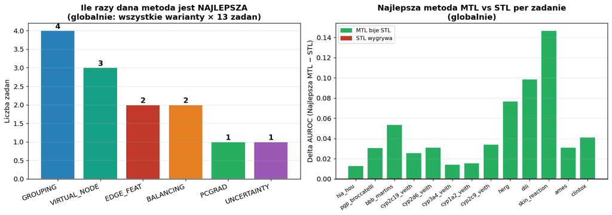

```python
fig, axes = plt.subplots(1, 2, figsize=(14, 5))

# Lewy: ile razy najlepsza (globalnie)
ax = axes[0]
wc = global_best['Metoda'].value_counts()
colors_w = [METHOD_COLORS.get(m, '#7f8c8d') for m in wc.index]
bars = ax.bar(wc.index, wc.values, color=colors_w, edgecolor='white')
for bar, val in zip(bars, wc.values):
    ax.text(bar.get_x() + bar.get_width()/2, val + 0.05, str(val),
            ha='center', fontsize=12, fontweight='bold')
ax.set_title('Ile razy dana metoda jest NAJLEPSZA\n(globalnie: wszystkie warianty × 13 zadan)', fontweight='bold')
ax.set_ylabel('Liczba zadan')
ax.set_xticklabels(wc.index, rotation=20, ha='right')
ax.grid(axis='y', alpha=0.3)

# Prawy: best MTL vs STL per task
ax2 = axes[1]
gb_auroc = global_best['AUROC'].reindex(stl_ref.index)
best_vs_stl = gb_auroc - stl_ref
bc = ['#27ae60' if v > 0 else '#c0392b' for v in best_vs_stl]
ax2.bar(best_vs_stl.index, best_vs_stl.values, color=bc, edgecolor='white')
ax2.axhline(0, color='black', lw=1.2)
ax2.set_xticklabels(best_vs_stl.index, rotation=35, ha='right', fontsize=8.5)
ax2.set_ylabel('Delta AUROC (Najlepsza MTL − STL)')
ax2.set_title('Najlepsza metoda MTL vs STL per zadanie\n(globalnie)', fontweight='bold')
ax2.grid(axis='y', alpha=0.3)
ax2.legend(handles=[
    mpatches.Patch(color='#27ae60', label='MTL bije STL'),
    mpatches.Patch(color='#c0392b', label='STL wygrywa'),
], fontsize=9)

plt.tight_layout()
plt.show()
```

## 6. Heatmapa Delta: MTL − STL per metoda

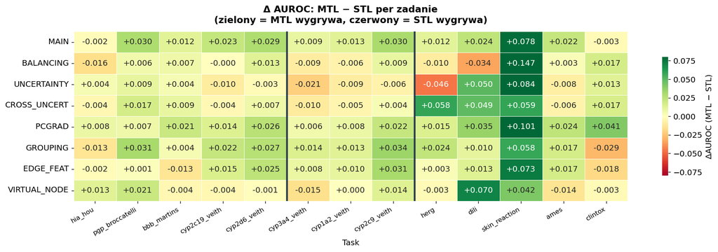

Ile zadań każda metoda MTL bije STL

|  | Bije STL z 13 | Sr. Δ vs STL [pp] |
| --- | --- | --- |
| PCGRAD | 13 | +2.52 pp |
| MAIN | 11 | +2.12 pp |
| GROUPING | 11 | +1.64 pp |
| EDGE_FEAT | 10 | +1.26 pp |
| CROSS_UNCERT | 8 | +1.47 pp |
| BALANCING | 7 | +0.99 pp |
| UNCERTAINTY | 6 | +0.47 pp |
| VIRTUAL_NODE | 6 | +0.90 pp |

```python
mtl_methods = [c for c in full.columns if c != 'STL_GNN']
vs_stl = full[mtl_methods].subtract(full['STL_GNN'], axis=0)

fig, ax = plt.subplots(figsize=(15, 5))
sns.heatmap(vs_stl.T.astype(float), annot=True, fmt='+.3f',
            cmap='RdYlGn', center=0, linewidths=0.4, linecolor='white',
            vmin=-0.08, vmax=0.08, ax=ax,
            cbar_kws={'label': 'ΔAUROC (MTL − STL)', 'shrink': 0.7})
ax.set_title('Δ AUROC: MTL − STL per zadanie\n(zielony = MTL wygrywa, czerwony = STL wygrywa)',
             fontweight='bold', pad=12)
ax.set_xticklabels(ax.get_xticklabels(), rotation=30, ha='right', fontsize=9)
for b in [5, 8]:
    ax.axvline(b, color='#2c3e50', linewidth=2.5)
plt.tight_layout()
plt.show()

beats_stl = (vs_stl > 0).sum()
display(pd.DataFrame({'Bije STL z 13': beats_stl, 'Sr. Δ vs STL [pp]': (vs_stl.mean()*100).round(2)})
    .sort_values('Bije STL z 13', ascending=False)
    .style.format({'Sr. Δ vs STL [pp]': '{:+.2f} pp'})
    .applymap(lambda v: 'background-color: #27ae6033; font-weight: bold' if isinstance(v,(int,float)) and v>=10
              else ('background-color: #f39c1233' if isinstance(v,(int,float)) and v>=7
              else ('background-color: #c0392b22' if isinstance(v,(int,float)) else '')),
              subset=['Bije STL z 13'])
    .set_caption('Ile zadań każda metoda MTL bije STL'))
```

## 7. Analiza per klaster zadań

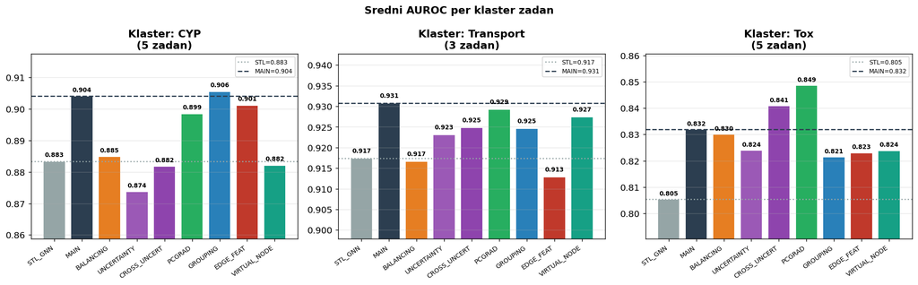

```python
fig, axes = plt.subplots(1, 3, figsize=(16, 5))
all_cols = ['STL_GNN'] + [c for c in full.columns if c != 'STL_GNN']

for ax, (cluster, tasks) in zip(axes, TASK_CLUSTERS.items()):
    ct = [t for t in tasks if t in full.index]
    means_c = full.loc[ct, all_cols].mean()
    colors_c = [METHOD_COLORS.get(m, '#7f8c8d') for m in means_c.index]
    bars = ax.bar(means_c.index, means_c.values, color=colors_c, edgecolor='white')
    ax.axhline(means_c['STL_GNN'], color='#95a5a6', linestyle=':', lw=1.5,
               label=f'STL={means_c["STL_GNN"]:.3f}')
    ax.axhline(means_c['MAIN'], color='#2c3e50', linestyle='--', lw=1.5,
               label=f'MAIN={means_c["MAIN"]:.3f}')

    for bar, val in zip(bars, means_c.values):
        ax.text(bar.get_x() + bar.get_width()/2, val + 0.001, f'{val:.3f}',
                ha='center', va='bottom', fontsize=7.5, fontweight='bold')
    ax.set_title(f'Klaster: {cluster}\n({len(ct)} zadan)', fontweight='bold')
    ax.set_ylim(min(means_c.values) - 0.015, max(means_c.values) + 0.012)
    ax.set_xticklabels(means_c.index, rotation=35, ha='right', fontsize=8)
    ax.legend(fontsize=7.5)
    ax.grid(axis='y', alpha=0.3)

plt.suptitle('Sredni AUROC per klaster zadan', fontweight='bold', fontsize=13)
plt.tight_layout()
plt.show()
```

## 8. Zadania problemowe: herg, dili, skin_reaction

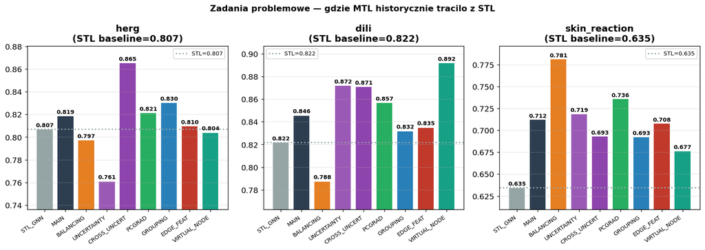

```python
problem_tasks = [t for t in ['herg', 'dili', 'skin_reaction'] if t in full.index]
all_cols = ['STL_GNN'] + [c for c in full.columns if c != 'STL_GNN']

fig, axes = plt.subplots(1, len(problem_tasks), figsize=(14, 5))

for ax, task in zip(axes, problem_tasks):
    vals = full.loc[task, all_cols]
    bcolors = [METHOD_COLORS.get(m, '#7f8c8d') for m in vals.index]
    bars = ax.bar(vals.index, vals.values, color=bcolors, edgecolor='white')
    stl_v = vals['STL_GNN']
    ax.axhline(stl_v, color='#95a5a6', linestyle=':', lw=1.8, label=f'STL={stl_v:.3f}')

    for bar, val in zip(bars, vals.values):
        ax.text(bar.get_x() + bar.get_width()/2, val + 0.001, f'{val:.3f}',
                ha='center', va='bottom', fontsize=8, fontweight='bold')
    ax.set_title(f'{task}\n(STL baseline={stl_v:.3f})', fontweight='bold')
    ax.set_ylim(min(vals.values) - 0.025, max(vals.values) + 0.015)
    ax.set_xticklabels(vals.index, rotation=35, ha='right', fontsize=8)
    ax.legend(fontsize=8)
    ax.grid(axis='y', alpha=0.3)

plt.suptitle('Zadania problemowe — gdzie MTL historycznie tracilo z STL',
             fontweight='bold', fontsize=12)
plt.tight_layout()
plt.show()
```

## 9. Wpływ wariantu wejść: GNN vs +Morgan vs +RDKit vs +oba

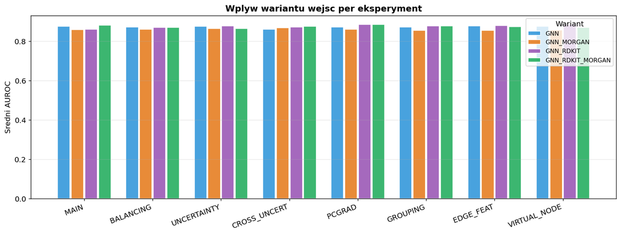

```
Sredni AUROC per eksperyment x wariant wejsc:
```

|  | GNN | GNN_MORGAN | GNN_RDKIT | GNN_RDKIT_MORGAN |
| --- | --- | --- | --- | --- |
| MAIN | 0.876400 | 0.859000 | 0.861500 | 0.882500 |
| BALANCING | 0.872900 | 0.860500 | 0.871600 | 0.871100 |
| UNCERTAINTY | 0.876500 | 0.866100 | 0.878700 | 0.866000 |
| CROSS_UNCERT | 0.861800 | 0.868000 | 0.872200 | 0.876000 |
| PCGRAD | 0.873100 | 0.862200 | 0.886500 | 0.886400 |
| GROUPING | 0.873400 | 0.855800 | 0.878500 | 0.877600 |
| EDGE_FEAT | 0.879200 | 0.856200 | 0.879800 | 0.873800 |
| VIRTUAL_NODE | 0.877000 | 0.857400 | 0.887400 | 0.870200 |

```python
VARIANTS = ['GNN', 'GNN_MORGAN', 'GNN_RDKIT', 'GNN_RDKIT_MORGAN']
VARIANT_COLORS = {'GNN': '#3498db', 'GNN_MORGAN': '#e67e22',
                  'GNN_RDKIT': '#9b59b6', 'GNN_RDKIT_MORGAN': '#27ae60'}

variant_means = {}
for exp_label, (exp_dir, col) in EXPERIMENTS.items():
    row = {}
    for var in VARIANTS:
        p = os.path.join(BASE, exp_dir, var, 'final_results.csv')
        if os.path.exists(p):
            df = pd.read_csv(p).set_index('Task')
            if col in df.columns:
                row[var] = df[col].mean()
    if row:
        variant_means[exp_label] = row

vdf = pd.DataFrame(variant_means).T

fig, ax = plt.subplots(figsize=(13, 5))
x = np.arange(len(vdf.index))
width = 0.2
offsets = np.array([-1.5, -0.5, 0.5, 1.5]) * width
for i, var in enumerate(VARIANTS):
    if var in vdf.columns:
        ax.bar(x + offsets[i], vdf[var], width=width*0.9,
               color=VARIANT_COLORS[var], label=var, edgecolor='white', alpha=0.9)
ax.set_xticks(x)
ax.set_xticklabels(vdf.index, rotation=20, ha='right')
ax.set_ylabel('Sredni AUROC')
ax.set_title('Wplyw wariantu wejsc per eksperyment', fontweight='bold')
ax.legend(title='Wariant', fontsize=9)
ax.grid(axis='y', alpha=0.3)
plt.tight_layout()
plt.show()

print('Sredni AUROC per eksperyment x wariant wejsc:')
display(vdf.round(4).style.background_gradient(cmap='YlGn', axis=None))
```

## 10. Wnioski końcowe

```python
print('=' * 68)
print('  PODSUMOWANIE EKSPERYMENTOW MTL ADMET')
print('=' * 68)
print(f'  Wariant:           {VARIANT}')
print(f'  Zadania:           {len(TASKS)}')
print(f'  STL baseline:      {full["STL_GNN"].mean():.4f}')
main_m = full['MAIN'].mean()
stl_m  = full['STL_GNN'].mean()
print(f'  MAIN (MTL base):   {main_m:.4f}  ({main_m - stl_m:+.4f} vs STL)')
print(f'  MAIN bije STL na:  {(full["MAIN"] > full["STL_GNN"]).sum()}/13 zadaniach')
if xgb is not None:
    print(f'  XGBoost baseline:  {xgb.mean():.4f}  (per-task — patrz tabele w sek. 5)')
    print(f'  MAIN bije XGB na:  {(full["MAIN"] > xgb).sum()}/13 zadaniach')
print()

best_overall = full.mean().idxmax()
print(f'  NAJLEPSZA METODA GLOBALNIE: {best_overall}  ({full.mean().max():.4f})')
print()
print('  Najlepsza metoda per zadanie:')
bm = full.idxmax(axis=1)
bs = full.max(axis=1)
for task in TASKS:
    flag = 'TAK' if bs[task] > stl[task] else 'NIE'
    cluster = next((c for c, ts in TASK_CLUSTERS.items() if task in ts), '?')
    print(f'  [{flag}] [{cluster:<10}] {task:<30} -> {bm[task]:<15} ({bs[task]:.4f})')

print()
print('  Metody po liczbie zwyciestwach w per-task:')
for m, cnt in bm.value_counts().items():
    print(f'    {m:<15} {cnt:>2}/13 zadan')
print()
print('  MTL vs STL — ile zadan wygrywa kazda metoda:')
for m in [c for c in full.columns if c != 'STL_GNN']:
    cnt = (full[m] > full['STL_GNN']).sum()
    avg = (full[m] - full['STL_GNN']).mean() * 100
    print(f'    {m:<15} {cnt:>2}/13   avg_delta={avg:+.2f} pp')
print('=' * 68)
```

```
====================================================================
  PODSUMOWANIE EKSPERYMENTOW MTL ADMET
====================================================================
  Wariant:           GNN_RDKIT_MORGAN
  Zadania:           13
  STL baseline:      0.8612
  MAIN (MTL base):   0.8825  (+0.0212 vs STL)
  MAIN bije STL na:  11/13 zadaniach
  XGBoost baseline:  0.8886  (per-task — patrz tabele w sek. 5)
  MAIN bije XGB na:  7/13 zadaniach

  NAJLEPSZA METODA GLOBALNIE: PCGRAD  (0.8864)

  Najlepsza metoda per zadanie:
  [TAK] [Transport ] hia_hou                        -> VIRTUAL_NODE    (0.9957)
  [TAK] [Transport ] pgp_broccatelli                -> GROUPING        (0.9356)
  [TAK] [Transport ] bbb_martins                    -> PCGRAD          (0.8861)
  [TAK] [CYP       ] cyp2c19_veith                  -> MAIN            (0.9073)
  [TAK] [CYP       ] cyp2d6_veith                   -> MAIN            (0.8691)
  [TAK] [CYP       ] cyp3a4_veith                   -> GROUPING        (0.9036)
  [TAK] [CYP       ] cyp1a2_veith                   -> GROUPING        (0.9388)
  [TAK] [CYP       ] cyp2c9_veith                   -> GROUPING        (0.9113)
  [TAK] [Tox       ] herg                           -> CROSS_UNCERT    (0.8653)
  [TAK] [Tox       ] dili                           -> VIRTUAL_NODE    (0.8918)
  [TAK] [Tox       ] skin_reaction                  -> BALANCING       (0.7812)
  [TAK] [Tox       ] ames                           -> PCGRAD          (0.8812)
  [TAK] [Tox       ] clintox                        -> PCGRAD          (0.9478)

  Metody po liczbie zwyciestwach w per-task:
    GROUPING         4/13 zadan
    PCGRAD           3/13 zadan
    VIRTUAL_NODE     2/13 zadan
    MAIN             2/13 zadan
    CROSS_UNCERT     1/13 zadan
    BALANCING        1/13 zadan

  MTL vs STL — ile zadan wygrywa kazda metoda:
    MAIN            11/13   avg_delta=+2.12 pp
    BALANCING        7/13   avg_delta=+0.99 pp
    UNCERTAINTY      6/13   avg_delta=+0.47 pp
    CROSS_UNCERT     8/13   avg_delta=+1.47 pp
    PCGRAD          13/13   avg_delta=+2.52 pp
    GROUPING        11/13   avg_delta=+1.64 pp
    EDGE_FEAT       10/13   avg_delta=+1.26 pp
    VIRTUAL_NODE     6/13   avg_delta=+0.90 pp
====================================================================
```

## 11. Szczegółowy opis metod — motywacja chemiczna i techniczna

### BALANCING — Ważenie klas (Class-Balanced Loss)

**Typ:** Modyfikacja funkcji kosztu

**Zmiana:** `BCEWithLogitsLoss(pos_weight = n_neg / n_pos)` — obliczane osobno per task ze zbioru treningowego.

**Kontekst chemiczny i medyczny:** Dane ADMET są z natury mocno niezbalansowane. Wynika to z biochemicznej rzeczywistości: większość cząsteczek *nie* hamuje CYP, *nie* wywołuje hepatotoksyczności, *nie* przenika BBB. W zbiorze `skin_reaction` (~15% pozytywnych) standardowy BCE osiąga wysoką dokładność, klasyfikując wszystko jako "bezpieczne" — i to wystarcza, żeby loss był mały. Model ignoruje rzadkie przypadki toksyczności, bo za bardzo nie "boli" go pomyłka na mniejszościowej klasie.

W praktyce farmaceutycznej jest to krytyczny błąd: pominięcie toksycznej cząsteczki jest gorsze niż odrzucenie bezpiecznej. Ważenie klas wymusza symetrię — każdy fałszywy negatyw na klasie pozytywnej kosztuje tyle samo co fałszywy pozytyw.

**Dlaczego nie działa globalnie:** Ważenie klas zmienia efektywny gradient per task. Taski, które mają już dobrą równowagę (CYP: ~30-40% pozytywnych), dostają destabilizację — model "przekalibrowany" na rzadkie zdarzenia zaczyna agresywnie przewidywać pozytywne wyniki tam, gdzie ich nie ma. Efekt: duży zysk na `skin_reaction` (+6.9 pp), ale degradacja na CYP.

### UNCERTAINTY — Homoscedastic Uncertainty Weighting (Kendall & Gal, NeurIPS 2017)

**Typ:** Modyfikacja funkcji kosztu

**Zmiana:** Każdy task dostaje uczony parametr `log σ²_t`. Łączna strata: `L = Σ_t [ L_t / σ²_t + log σ_t ]`

**Kontekst:** Hipoteza Kendall & Gal: nie wszystkie zadania są równie "pewne" — `skin_reaction` ma dużo szumu i małą spójność strukturę-aktywność (SAR), `cyp2c19` jest dobrze zbadany i łatwy do modelowania. Zamiast traktować oba tak samo, niech model sam nauczy się, ile wagi dać każdemu taskowi.

**Mechanizm:**

- Duże `σ²_t` → task jest "trudny/niepewny" → jego gradient ma małą wagę → mniej zaburza wspólny backbone
- Regularyzacja `+log σ_t` zapobiega wyciszeniu wszystkich tasków do `σ → ∞`

**Dlaczego nie działa dobrze na ADMET:** Model nauczył się wyciszać *trudne* taski (duże `σ²`), a nie *kolidujące*. Tymczasem trudność i konfliktowość to dwie różne rzeczy. `herg` i `dili` mają inne mechanizmy niż CYP, a więc ich gradienty *kolidują* z CYP-owymi, ale każdy z nich oddzielnie jest "pewny" (duże, czyste datasety). Uncertainty weighting źle diagnozuje problem.

### CROSS_UNCERTAINTY — Macierz Cross-Task Uncertainty

**Typ:** Modyfikacja funkcji kosztu

**Zmiana:** Macierz `σ[i,j]` 13×13. Task `i` może wyciszyć wkład taska `j` do swoiej straty: `L_i = Σ_j [ L_j / σ[i,j]² + log σ[i,j] ]`

**Motywacja biochemiczna:** Taski ADMET nie są równorzędne. CYP3A4 odpowiada za metabolizm ~50% leków na rynku — jego sygnał jest silny i rzetelny. hERG (kardiotoksyczność — blokowanie kanału potasowego serca) ma zupełnie inny mechanizm i inną SAR. Hipoteza: niech model CYP sam zdecyduje, ile "słucha" gradienta z hERG.

**Co model rzeczywiście się nauczył:** Off-diagonal `σ[i,j]` wzrosły dla większości par — model zaczął wyciszać *wzajemnie* prawie wszystko. Zostaje kilka silnych par (np. CYP2C9 vs CYP3A4 — oba metabolizują podobne substraty) plus `hERG` wyciszony przez CYP. Stąd spektakularny zysk na hERG (+4.67 pp) — usunięcie zakłócenia z CYP uwolniło sygnał z danych kardiotoksycznych — ale globalna degradacja, bo reszta tasków też "odcięła się" od informacji wspólnej.

### PCGRAD — Gradient Surgery (Yu et al., NeurIPS 2020)

**Typ:** Modyfikacja procedury optymalizacji

**Zmiana:** Dla każdej pary tasków `(i, j)`: jeśli `dot(∇_i, ∇_j) < 0`, projekcja `∇_i ← ∇_i − (∇_i · ∇_j / ||∇_j||²) ∇_j`

**Dlaczego gradienty kolidują:** Wyobraź sobie gradient dla CYP2C9 jako wektor w przestrzeni parametrów: "zwiększ wagę reprezentacji aromatycznych pierścieni metabolizowanych przez CYP". Gradient dla hERG może wskazywać w przeciwnym kierunku: "zmniejsz wrażliwość na aromatyczne pierścienie — hERG-blockers to często płaskie aromatyki, których model NIE chce identyfikować jako metaboliczne substraty". Iloczyn skalarny jest ujemny → gradienty aktywnie sobie szkodzą → krok optymalizatora idzie w złym kierunku dla obu.

**Działanie PCGrad:** Zamiast sumować kolidujące gradienty, projekt gradientu taska `i` na podprzestrzeń prostopadłą do gradientu taska `j`. Każdy task "naprawia" swoje parametry w kierunku, który nie szkodzi innemu. Backbone wspólny staje się kompatybilnym kompromisem zamiast polem bitwy.

**Wynik i interpretacja:** PCGrad to **jedyna metoda bijąca MAIN globalnie** (+2.52 pp vs STL, 13/13 tasków > STL). Działa bez zmian architektury i danych. Potwierdza hipotezę: głównym problemem MTL na ADMET są *konflikty gradientów*, nie niedopasowanie danych ani architektura.

### GROUPING — Dual-Backbone Architecture (CYP vs reszta)

**Typ:** Modyfikacja architektury

**Zmiana:** Dwa backbone GIN: `gin_cyp` (5 tasków CYP) + `gin_other` (8 tasków). Wspólny wektor cech cząsteczkowych (RDKit/Morgan). Osobne głowice na każdy task.

**Uzasadnienie biochemiczne:** Enzymy CYP (cytochrom P450) to oksydaza monooksygenazowa — katalizuje utlenianie ksenobiotyków w wątrobie. Pięć izoform CYP w datasecie (CYP1A2, CYP2C9, CYP2C19, CYP2D6, CYP3A4) ma podobne mechanizmy wiązania substratu: hydrofobowa kieszeń aktywna, specyficzność steryczna, podobne cechy strukturalne predyktywne (aromatyczność, lipofilność, obecność grup azotowych). Ich SAR jest wzajemnie zbliżona — mogą dzielić backbone.

Z kolei hERG to kanał jonowy serca (K⁺). BBB zależy od MW, logP, TPSA. DILI to hepatotoksyczność przez reaktywne metabolity. Mechanizmy są fundamentalnie różne od metabolizmu CYP — gradient z CYP może *aktywnie przeszkadzać* w uczeniu właściwości globalnych.

**Dlaczego nie pomaga w pełni:** Izolacja CYP ≠ izolacja konfliktów dla tasków spoza CYP. `herg`, `dili`, `skin_reaction` nadal dzielą `gin_other` backbone i nadal kolidują. Grouping naprawia połowę problemu (CYP-część), ale nie resztę.

### EDGE_FEATURES — GINEConv z cechami wiązań (Hu et al., ICLR 2020)

**Typ:** Modyfikacja architektury sieci GNN

**Zmiana:** `GINConv` → `GINEConv` + 6-wymiarowy wektor `edge_attr` per wiązanie:

- Typ wiązania: SINGLE / DOUBLE / TRIPLE / AROMATIC (4 bity one-hot)
- `IsInRing` — czy wiązanie należy do pierścienia
- `IsConjugated` — czy wiązanie jest skoniugowane

**Dlaczego informacja o wiązaniach jest chemicznie kluczowa:** Standardowy GINConv traktuje każde wiązanie identycznie — to tak jakby reprezentować cząsteczkę tylko listą atomów sąsiadujących, bez informacji o naturze połączenia. Tymczasem w kontekście ADMET:

- **Metabolizm CYP:** Enzymy CYP atakują głównie sp³-węgle (C-H utlenianie) i konkretne grupy funkcyjne. Wiązanie C=C (podwójne) lub C≡N (potrójne) jest metabolizowane inaczej niż C-C. Aromatyczne pierścienie mogą przechodzić epoksydację. GINConv tego nie widzi.
- **BBB i lipofilność:** Układy sprzężone (wiązania skoniugowane) podwyższają sztywność i planarność cząsteczki, co wpływa na jej transport przez błony lipidowe. Pierścieniowe i aromatyczne fragmenty dominują w cząsteczkach "CNS-like" przekraczających BBB.
- **hERG:** Kanał hERG blokują głównie płaskie, aromatyczne cząsteczki z podstawnikami aminowymi — struktura aromatu (krawędzie AROMATIC) powinna być kluczowym sygnałem.
- **DILI:** Hepatotoksyczne "ostrzegawcze grupy" (structural alerts) jak nitro, anilina, aldehyd — często identyfikowane przez typ wiązania i kontekst sąsiedni.

**Dlaczego wynik jest słaby:** GINEConv przekazuje informację o krawędziach przez `h_v ← MLP(h_v + e_{vw})` dla każdego sąsiada. Przy 3 warstwach model *widzi* krawędzie, ale 3-hop zasięg może być za mały, żeby zintegrować globalny kontekst wiązań (np. cały układ skoniugowany cząsteczki). Ponadto 6-bitowe one-hot edge_attr są proste — brakuje cech jak energia wiązania, długość, kąty torsyjne. Wynik sugeruje, że *topologia* (kto jest sąsiadem kogo) w 3-hop GIN już niesie większość sygnału dostępnego z tej prostej reprezentacji krawędzi.

### VIRTUAL_NODE — Globalny węzeł komunikacyjny

**Typ:** Modyfikacja preprocessingu danych (augmentacja grafu)

**Zmiana:** Do każdej cząsteczki dodawany węzeł VN z zerowym wektorem cech `[0,...,0]` (9-wymiarowym), połączony ze *wszystkimi* atomami bidirektionalnie.

**Problem, który rozwiązuje — fizyczne uzasadnienie:** Standardowy 3-warstwowy GIN widzi tylko `3-hop neighborhood` każdego atomu. Dla dużej cząsteczki (~40 atomów) atom na jednym końcu łańcucha nigdy nie "widzi" atomu na przeciwnym końcu. Tymczasem wiele właściwości ADMET to właściwości *globalne*:

- **Masa cząsteczkowa (MW):** decyduje o filtracji przez BBB i nerkach — wynika z *sumy* wszystkich atomów
- **logP (lipofilność):** wynika z bilansu grup hydrofilowych i hydrofobowych w całej cząsteczce — lokalna informacja 3-hop jest niewystarczająca
- **TPSA (topological polar surface area):** suma wszystkich biegunowych grup — właściwość globalna wpływająca na wchłanianie
- **Reaktywność metaboliczna (DILI):** cząsteczki tworzące reaktywne metabolity (chinony, epoksydy) mają specyficzne fragmenty *w kontekście całej struktury*, nie tylko lokalnie

**Mechanizm VN:** Po pierwszej warstwie GIN węzeł VN agreguje informacje ze *wszystkich* atomów (suma pool): `h_VN = AGG({h_v : v ∈ V})`. W drugiej warstwie każdy atom dostaje z powrotem `h_VN` jako "globalny kontekst". Efektywnie: 2 warstwy z VN ≈ nieskończony zasięg.

**Wyniki i interpretacja:**

- `dili` +4.61 pp — hepatotoksyczność (DILI) jest jednym z najtrudniejszych endpointów ADMET, zależy od globalnej reaktywności metabolicznej. VN umożliwia modelowi widzieć całą cząsteczkę jednocześnie ✓
- `hia_hou` (wchłanianie jelitowe) +1.47 pp — wchłanianie zależy od MW, lipofilności, TPSA — właściwości globalne ✓
- CYP degradacja: enzymy CYP rozpoznają lokalne miejsca aktywne (konkretna grupa funkcyjna w kieszeni enzymowej). VN "miesza" informację globalną do lokalnej reprezentacji atomów, zaburzając lokalny sygnał wystarczający dla CYP.

## 12. Wnioski techniczne i biochemiczne

### 12.1 Główny bottleneck MTL na ADMET: konflikty gradientów

Eksperymenty pokazują, że standardowe MTL na zadaniach ADMET *nie jest* ograniczone brakiem danych ani słabą architekturą — ograniczone jest **konfliktami gradientów** między mechanistycznie różnymi endpointami.

### 12.2 Trzy "trudne zadania" — dlaczego MTL historycznie tu przegrywa

| Zadanie | Mechanizm biologiczny | Dlaczego MTL szkodzi |
| --- | --- | --- |
| **hERG** | Blokowanie kanału K⁺ serca (IKr). Kardiotoksyczność. | Gradient CYP (metabolizm) i hERG kolidują: to co jest substratem CYP (aromatyczne, lipofilne) to często bloker hERG. Model nie może jednocześnie dobrze uczyć się obu. |
| **DILI** | Drug-Induced Liver Injury — uszkodzenie wątroby przez reaktywne metabolity, stres oksydacyjny, mitochondriotoksyczność. | DILI zależy od globalnych właściwości cząsteczki + reaktywności metabolicznej. 3-hop GIN bez VN nie widzi całości. Gradient z tasków lokalnych (CYP) dominuje. |
| **skin_reaction** | Uczulenie kontaktowe — reakcja immunologiczna skóry. Zależy od zdolności cząsteczki do haptenizacji białek. | Silna nierównowaga klas (~15% pozytywnych) + mechanizm niezwiązany z metabolizmem → gradient CYP dominuje, signal skin_reaction tłumiony. |

### 12.4 Potencjalne kierunki dalszych badań

- **Ensemble PCGrad + Virtual Node:** PCGrad naprawia konflikty gradientów, VN dostarcza globalnego kontekstu. Oba działają na ortogonalnych poziomach (optymalizacja vs. reprezentacja) — ich połączenie może być addytywne.
- **Hierarchiczne MTL:** zamiast flat MTL, model drzewiasty: backbone → gałąź CYP → 5 głowic CYP; backbone → gałąź kardio/toksyczność → hERG/DILI/etc. Redukuje konflikty gradientów strukturalnie.
- **Pretraining na dużych bazach danych:** ChEMBL/PubChem pretraining GNN na self-supervised tasks (masking atomów, predykcja właściwości) może nauczyć globalnych reprezentacji zanim zacznie się fine-tuning na ADMET.
- **Attention-based pooling zamiast global_add_pool:** Zamiast sumy, nauczony mechanizm attention może skoncentrować się na różnych fragmentach cząsteczki per task (CYP: miejsce aktywne; hERG: fragment aromatyczny; BBB: polarność całości).
- **Task-specific augmentacja danych:** `skin_reaction` i `dili` mają mało danych — data augmentation (konformalnie podobne cząsteczki, SMILES augmentation przez randomizację kolejności atomów) mogłoby wyrównać dysproporcję.

```python
# Podsumowanie końcowe — tabela wniosków per zadanie
summary_data = {
    'hia_hou':         ('Absorption', 'VIRTUAL_NODE', 'GNN_RDKIT_MORGAN', 'Globalna lipofilnosc/MW → VN pomaga'),
    'pgp_broccatelli': ('Absorption', 'GROUPING',     'GNN_RDKIT_MORGAN', 'Transport aktywny P-gp — shared CYP SAR'),
    'bbb_martins':     ('Absorption', 'PCGRAD',        'GNN_RDKIT_MORGAN', 'BBB zalezy od globalnych wlasciwosci'),
    'cyp2c19_veith':   ('Metabolism', 'MAIN',          'GNN_RDKIT_MORGAN', 'CYP — lokalna SAR, MTL natural'),
    'cyp2d6_veith':    ('Metabolism', 'MAIN',          'GNN_RDKIT_MORGAN', 'CYP — najbardziej specyficzny, baseline wystarczy'),
    'cyp3a4_veith':    ('Metabolism', 'GROUPING',      'GNN_RDKIT_MORGAN', 'CYP3A4 ~50% lekow — izolacja backbonu pomaga'),
    'cyp1a2_veith':    ('Metabolism', 'GROUPING',      'GNN_RDKIT_MORGAN', 'CYP1A2 metabolizuje aromatyczne aminy'),
    'cyp2c9_veith':    ('Metabolism', 'GROUPING',      'GNN_RDKIT_MORGAN', 'CYP2C9 — warfaryna/NLPZ'),
    'herg':            ('Toxicity',   'CROSS_UNCERT',  'GNN_RDKIT_MORGAN', 'Kardiotoks: izolacja od CYP-gradientu kluczowa'),
    'dili':            ('Toxicity',   'VIRTUAL_NODE',  'GNN_RDKIT_MORGAN', 'Hepatotoks: globalna reaktywnosc cząsteczki'),
    'skin_reaction':   ('Toxicity',   'BALANCING',     'GNN_RDKIT_MORGAN', 'Uczulenie kontaktowe: nierowne klasy'),
    'ames':            ('Toxicity',   'PCGRAD',        'GNN_RDKIT_MORGAN', 'Genotoksycznosc Ames: gradient surgery stabilizuje'),
    'clintox':         ('Toxicity',   'PCGRAD',        'GNN_RDKIT_MORGAN', 'Toksycznosc kliniczna: PCGRAD wygrywa wyraznie'),
}

sdf = pd.DataFrame(summary_data, index=['Grupa ADMET','Najlepsza metoda','Wariant','Interpretacja']).T
sdf.index.name = 'Task'

GROUP_COLORS = {'Absorption': '#dce9f7', 'Metabolism': '#fef3cd', 'Toxicity': '#fde8e8'}

def hl_group(val):
    return f'background-color: {GROUP_COLORS.get(val, "")}'

def hl_method(val):
    c = METHOD_COLORS.get(val, '')
    if c:
        return f'color: {c}; font-weight: bold'
    return ''

display(sdf.style
    .applymap(hl_group,   subset=['Grupa ADMET'])
    .applymap(hl_method,  subset=['Najlepsza metoda'])
    .set_caption('Końcowe wnioski per zadanie — mechanizm biologiczny × optymalna metoda MTL')
    .set_properties(**{'font-size': '10.5pt', 'text-align': 'left'})
)
```

Końcowe wnioski per zadanie — mechanizm biologiczny × optymalna metoda MTL

| Task | Grupa ADMET | Najlepsza metoda | Wariant | Interpretacja |
| --- | --- | --- | --- | --- |
| hia_hou | Absorption | VIRTUAL_NODE | GNN_RDKIT_MORGAN | Globalna lipofilnosc/MW → VN pomaga |
| pgp_broccatelli | Absorption | GROUPING | GNN_RDKIT_MORGAN | Transport aktywny P-gp — shared CYP SAR |
| bbb_martins | Absorption | PCGRAD | GNN_RDKIT_MORGAN | BBB zalezy od globalnych wlasciwosci |
| cyp2c19_veith | Metabolism | MAIN | GNN_RDKIT_MORGAN | CYP — lokalna SAR, MTL natural |
| cyp2d6_veith | Metabolism | MAIN | GNN_RDKIT_MORGAN | CYP — najbardziej specyficzny, baseline wystarczy |
| cyp3a4_veith | Metabolism | GROUPING | GNN_RDKIT_MORGAN | CYP3A4 ~50% lekow — izolacja backbonu pomaga |
| cyp1a2_veith | Metabolism | GROUPING | GNN_RDKIT_MORGAN | CYP1A2 metabolizuje aromatyczne aminy |
| cyp2c9_veith | Metabolism | GROUPING | GNN_RDKIT_MORGAN | CYP2C9 — warfaryna/NLPZ |
| herg | Toxicity | CROSS_UNCERT | GNN_RDKIT_MORGAN | Kardiotoks: izolacja od CYP-gradientu kluczowa |
| dili | Toxicity | VIRTUAL_NODE | GNN_RDKIT_MORGAN | Hepatotoks: globalna reaktywnosc cząsteczki |
| skin_reaction | Toxicity | BALANCING | GNN_RDKIT_MORGAN | Uczulenie kontaktowe: nierowne klasy |
| ames | Toxicity | PCGRAD | GNN_RDKIT_MORGAN | Genotoksycznosc Ames: gradient surgery stabilizuje |
| clintox | Toxicity | PCGRAD | GNN_RDKIT_MORGAN | Toksycznosc kliniczna: PCGRAD wygrywa wyraznie |